# Project2

Chuanni He

2022-10-12

# Backgroun Information

This project is prepared by Aniket Anil Walimbe and Chuanni He. It created a vignette for reading and summarizing data from one of the [Financial data API](https://polygon.io/docs/getting-started).

# Requirements

To use the functions for interacting with the Financial API, We used the following packages:  
* `httr`: Tools for Working with URLs and HTTP.  
* `jsonlite`: A JSON parser/generator optimized for the web. Its main strength is that it implements a bidirectional mapping between JSON data and the most important R data types.  
* `ggplot2`: A system for declaratively creating graphics, based on The Grammar of Graphics.  
* `tidyverse`: An opinionated collection of R packages designed for data science. All packages share an underlying design philosophy, grammar, and data structures.

```r
# Required library and key information
key = "EByG3OEye377G2rI0LRah2CUjGplA7TB"
library(httr)
library(jsonlite)
library(ggplot2)
library(tidyverse)
```

# API Interaction Functions

This section talks about how we define the functions to interact with the Financial API, as well as some helper functions working with data manipulation.

## `Aggregates`

```r
Aggregates = function(ticker,multiplier, timespan) {
  # generate the URL
  base = "https://api.polygon.io/v2/aggs/"
  Endpoint = "ticker"
  ticker = toupper(ticker)
  timespan = tolower(timespan)
  call = paste(base,Endpoint,"/",ticker,"/range/",multiplier,"/",timespan,
               "/2021-07-22/2022-07-22?adjusted=true&sort=asc&limit=200&apiKey=",
               key, sep = "")
  # Acquire the data
  get = GET(call)
  parsed = fromJSON(rawToChar(get$content))
  result = parsed$results
  colnames(result) = c("TradingVolumn", "VolumnWeightedAverage",
                       "OpenPrice","ClosePrice", "HighestPrice",
                       "LowestPrice","Timestamp","Transactions")

  return(result)
}
```

## `GetNews`

```r
GetNews = function(ticker, published, limit) {
  ticker = toupper(ticker)
  # generate the URL
  base = "https://api.polygon.io/v2/reference/"
  Endpoint = "news"
  call = paste(base,Endpoint,"?ticker=",ticker,"&published_utc.gt=",published,
               "&limit=",limit, "&apiKey=", key, sep = "")
  # Acquire the data
  get = GET(call)
  parsed = fromJSON(rawToChar(get$content))
  # We removed the publisher information
  result = parsed$results[,-2]
  return(result)
}
```

# Data Exploration

Now that we can interact with a few of the endpoints of the Financial API, let’s get some data from them. Here, we defined the scope of this project to investigate two types of companies: technical companies and financial companies. The specific companies we will focus on are: * Apple Inc. (`AAPL`) * Amazon Inc. (`AMZN`) * JPMorgan Chase & Co (`JPM`) * Wells Fargo & Co (`WFC`)

First, let’s pull the stock price of Apple Inc. (the ticker is `AAPL`) and Amazon.com Inc. (the ticker is `AMZN`) during 2021-7-22 and 2022-7-22. We set the timeframe as 1 day (`multiplier=1`, `timespan="day"`), then, we call the function `Aggregates("aapl", 1, "day")` and `Aggregates("amzn", 1, "day")`. Then combine them together by adding a `Company` variable.

```r
Price_Apple = Aggregates("aapl", 1, "day")
Price_Amazon = Aggregates("amzn", 1, "day")

Price_Apple = data.frame(Company="Apple",Price_Apple)
Price_Amazon = data.frame(Company="Amazon",Price_Amazon)
Price = rbind(Price_Apple,Price_Amazon)

head(Price)
```

```
##   Company TradingVolumn VolumnWeightedAverage OpenPrice ClosePrice HighestPrice
## 1   Apple      77287356              146.9910   145.935     146.80     148.1950
## 2   Apple      71447416              148.0368   147.550     148.56     148.7177
## 3   Apple      72434089              149.1182   148.270     148.99     149.8300
## 4   Apple     104803028              146.8324   149.120     146.77     149.2100
## 5   Apple     118931191              144.8875   144.810     144.98     146.9700
## 6   Apple      56699475              145.8064   144.685     145.64     146.5500
##   LowestPrice    Timestamp Transactions
## 1      145.81 1.626926e+12       480209
## 2      146.92 1.627013e+12       457247
## 3      147.70 1.627272e+12       489114
## 4      145.55 1.627358e+12       785621
## 5      142.54 1.627445e+12       829463
## 6      144.58 1.627531e+12       416123
```

# Exploratory Data Analysis

## Trend for Openning Price

We have called the function twice to obtain the data for Apple and Amazon companies. We have then plotted the opening price for the stocks against the timestamp for doing various analysis like identifying the trends etc.

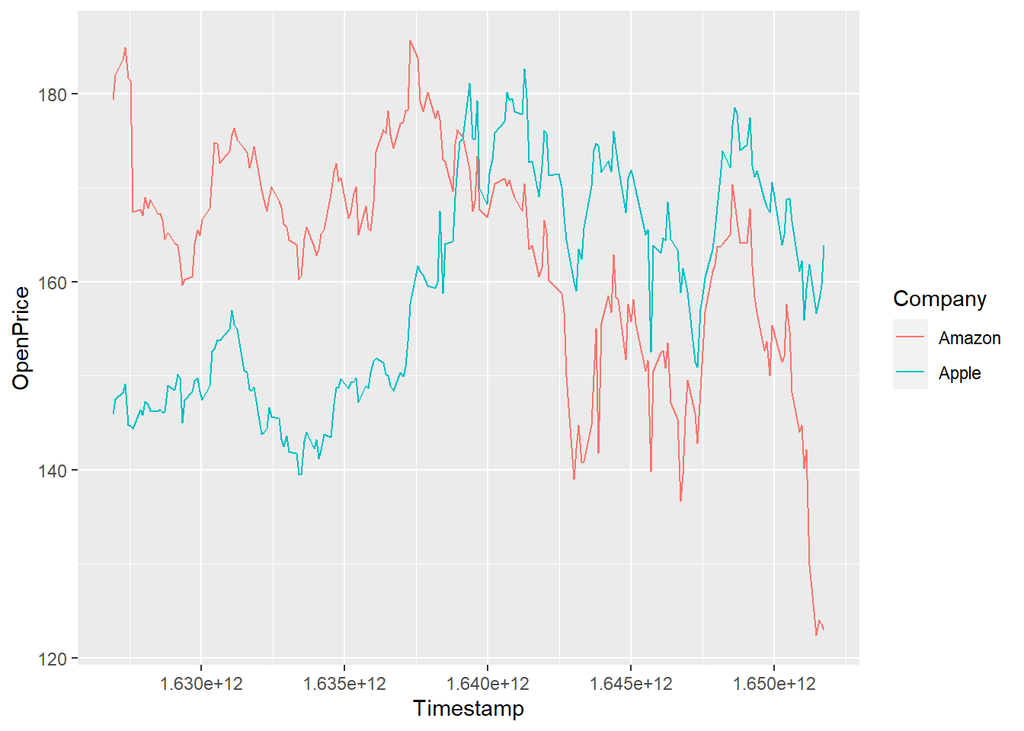

Open price for Amazon and Apple

```r
ggplot(data = Price, aes(x = Timestamp, y = OpenPrice)) +
geom_line(aes(color = Company))
```

From the plot above, we can found that there is a decreasing major trend for Amazon and a rising trend for Apple. In addition, the two companies share similar fluctuation trend in a small timeframe (can be interpreted as being impacted by the entire market). When there is a rising thrend, both of them tend to have a increasing pattern, and vise versa.

## Creating New Variables

Next, we have created a new variable `PriceVariation` which is the difference between the highest and lowest price of the stocks of a company per day. The new variable represents the fluctuation range of the corresponding company. This variation is then plotted against the timestamp and following graph is obtained.

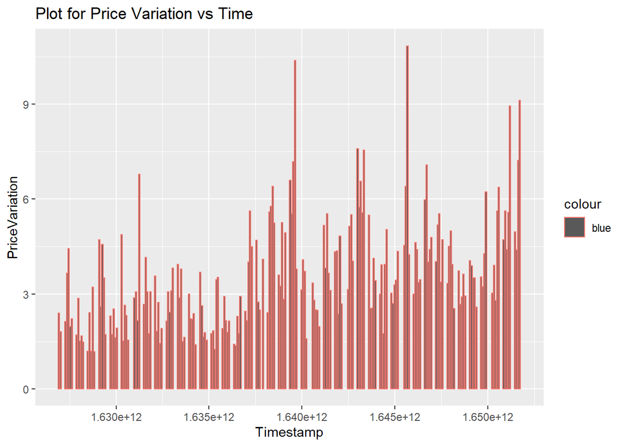

Plot for Price Variation vs Time

```r
priceUpdated <- Price %>%
  filter(Company == "Apple") %>%
  mutate(PriceVariation = (HighestPrice-LowestPrice)) %>%
  arrange(desc(PriceVariation))

ggplot(data = priceUpdated, aes(x = Timestamp, y = PriceVariation, color = "blue")) +
  geom_col() +
  labs(title = "Plot for Price Variation vs Time")
```

From the plot above, we can find that there is no clear pattern for the daily fluctuation for Apple Inc. However, in the past year, there is a minor increasing trend for the daily fluctuation, indicating that the stock for Apple is becoming more insteable.

## Numerical Summaries for Categorical Variables

Since we limited our scope of this project to focus on four companies, here for each company, we calculated the summary statistics for the `PriceVariation` of all the four companies.

```r
Price_JPMORGAN = Aggregates("jpm", 1, "day")
Price_WELLSFARGO = Aggregates("wfc", 1, "day")
Price_JPMORGAN = data.frame(Company="JPMorgan",Price_JPMORGAN)
Price_WELLSFARGO = data.frame(Company="Wells Fargo",Price_WELLSFARGO)
Price = rbind(Price,Price_JPMORGAN,Price_WELLSFARGO)

priceNew <- Price %>%
  mutate(PriceVariation = (HighestPrice-LowestPrice))

Price_Summary = priceNew %>% group_by(Company) %>%
                summarize("Min." = min(PriceVariation),
                          "1st Quartile" = quantile(PriceVariation, 0.25, na.rm=TRUE),
                          "Median" = quantile(PriceVariation, 0.5, na.rm=TRUE),
                          "Mean" = mean(PriceVariation, na.rm=TRUE),
                          "3rd Quartile" = quantile(PriceVariation, 0.75, na.rm=TRUE),
                          "Max" = max(PriceVariation),
                          "Std. Dev." = sd(PriceVariation, na.rm=TRUE))
Price_Summary
```

```
## # A tibble: 4 × 8
##   Company      Min. `1st Quartile` Median  Mean `3rd Quartile`   Max `Std. Dev.`
##   <chr>       <dbl>          <dbl>  <dbl> <dbl>          <dbl> <dbl>       <dbl>
## 1 Amazon      1.09           2.72    3.82  4.21           5.38 12.2        1.93
## 2 Apple       1.17           2.38    3.34  3.61           4.49 10.8        1.72
## 3 JPMorgan    1.33           2.21    2.85  3.08           3.72  6.90       1.08
## 4 Wells Fargo 0.485          0.999   1.19  1.32           1.57  3.78       0.533
```

Wells Fargo has the least daily variation, indicating that the stock is very steable in a daily timeframe. Technical companies have overall higher daily fluctuation than financial companies.

```r
Price_StatsOP <- Price %>%
  group_by(Company) %>%
  summarise(Avg_Open_Price = mean(OpenPrice), Std_dev = sd(OpenPrice), Median = median(OpenPrice), IQR = IQR(OpenPrice))

Price_StatsCP <- Price %>%
  group_by(Company) %>%
  summarise(Avg_Close_Price = mean(ClosePrice), Std_dev = sd(ClosePrice), Median = median(ClosePrice), IQR = IQR(ClosePrice))


Price_StatsOP
```

```
## # A tibble: 4 × 5
##   Company     Avg_Open_Price Std_dev Median   IQR
##   <chr>                <dbl>   <dbl>  <dbl> <dbl>
## 1 Amazon               163.    12.2   166.  14.0
## 2 Apple                159.    11.7   159.  21.5
## 3 JPMorgan             153.    13.5   157.  19.6
## 4 Wells Fargo           49.7    3.58   49.2  4.13
```

```r
Price_StatsCP
```

```
## # A tibble: 4 × 5
##   Company     Avg_Close_Price Std_dev Median   IQR
##   <chr>                 <dbl>   <dbl>  <dbl> <dbl>
## 1 Amazon                163.    12.5   165.  15.0
## 2 Apple                 160.    11.7   160.  21.5
## 3 JPMorgan              153.    13.4   157.  18.0
## 4 Wells Fargo            49.7    3.57   48.9  4.14
```

Some findings can be concluded form the data above. First, Amazon has slightly higher open and close price than Apple. Both of them have almost the same standard deviation regarding the open and close price. In addition, Apple has significantly higher IQR than Amazon.

## Contingency Tables

Next, let’s create some contingency tables to summarize the key words for different types of companies in the news. We are interested in the key words in news for two types of companies: technology company and finance company. We selected `AAPL` and `AMZN` as technical company samples, `JPM` and `WFC` as financial company samples.

```r
News_AAPL = GetNews("aapl","2021-07-01",500)
wordvec_AAPL = tolower(unlist(News_AAPL$keywords))

News_AMZN = GetNews("amzn","2021-07-01",500)
wordvec_AMZN = tolower(unlist(News_AMZN$keywords))

News_JPM = GetNews("jpm","2021-07-01",500)
wordvec_JPM = tolower(unlist(News_JPM$keywords))

News_WFC = GetNews("wfc","2021-07-01",500)
worvec_WFC = tolower(unlist(News_WFC$keywords))
```

We grabbed the keywords in the first 500 news of the corresponding companies from 2021-07-01, save it as a string vector. Then we want to search for the keywords of `tech`, `investing`, and `markets` in the news from the four companies. We first create a `keywords` vector to save the word list. Next we search for the keywords in the corresponding string vectors, and create four contingency tables accordingly.

```r
keywords = c("tech", "investing","markets","eurozone")
wordcount_AAPL = wordvec_AAPL[wordvec_AAPL %in% keywords]
wordcount_AMZN = wordvec_AMZN[wordvec_AMZN %in% keywords]
wordcount_JPM = wordvec_JPM[wordvec_JPM %in% keywords]
wordcount_WFC = worvec_WFC[worvec_WFC %in% keywords]

table(wordcount_AAPL)
```

```
## wordcount_AAPL
## investing   markets      tech
##       134        62        69
```

```r
table(wordcount_AMZN)
```

```
## wordcount_AMZN
##  eurozone investing   markets      tech
##         1       190        60        26
```

```r
table(wordcount_JPM)
```

```
## wordcount_JPM
##  eurozone investing   markets      tech
##         4       118        27         4
```

```r
table(wordcount_WFC)
```

```
## wordcount_WFC
##  eurozone investing   markets      tech
##         3       129        29         2
```

It can be seen that there is a clear association between the keywords and company types. Two technical companies all includes keyword of `tech`, while either of the financial companies has fewer frequency of `tech`. On the other hand, financial terminology such as `eurozone` has higher frequencies in financial companies.

## Investigating the Keyword Count for Different Companies

In this plot, we have first converted the `wordcount_AAPL` list to a tibble and then, plotted the keywords present in the table according to their values.

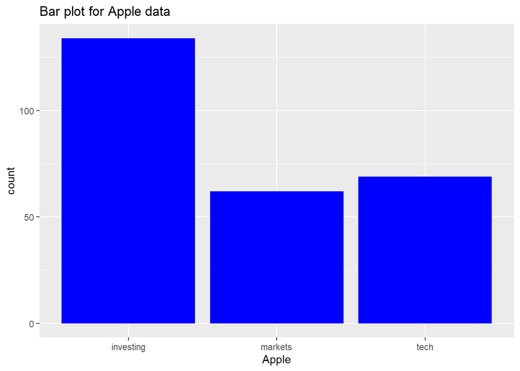

Bar plot for Apple data

```r
df_temp <- as_tibble(wordcount_AAPL)
ggplot(data = df_temp, aes(x = value)) +
  geom_bar(fill="blue") +
  labs(x = "Apple", title = "Bar plot for Apple data")
```

It can be found that `investing` is a high frequency word over Apple, indicating that the news are potentially focusing on financial investment analysis or suggestions, etc.

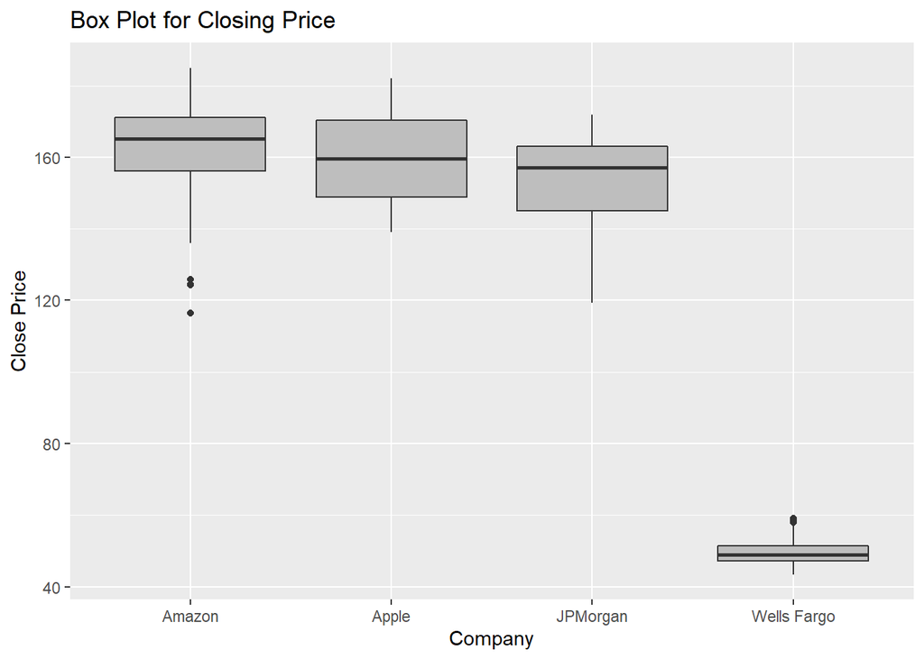

Box Plot for Closing Price

```r
ggplot(data = Price, aes(x = Company, y = ClosePrice)) +
  geom_boxplot(fill = "grey")+
  labs(y = "Close Price", title = "Box Plot for Closing Price" )
```

As identified in the data summary, Amazon has slightly higher average close price than Apple, while Apple has higher IQR than Amazon.

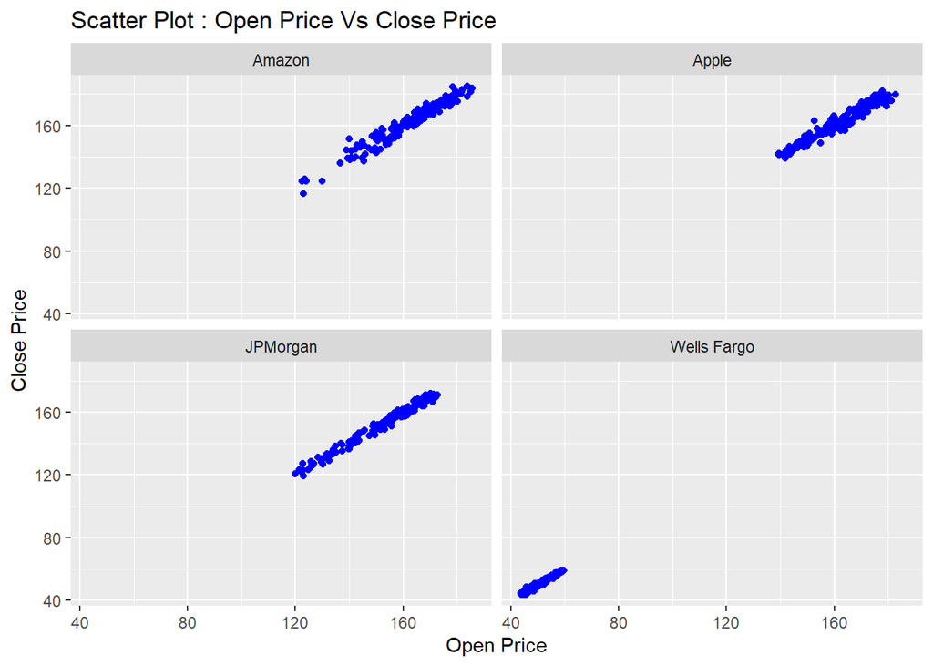

Scatter Plot : Open Price Vs Close Price

```r
ggplot(data = Price, aes(x = OpenPrice, y = ClosePrice)) +
  geom_point(color = "blue") +
  labs(x = "Open Price" , y = "Close Price", title = "Scatter Plot : Open Price Vs Close Price") +
  facet_wrap(~ Company)
```

Finally, the histogram of the Transactions for Amazon stocks is developed as well.

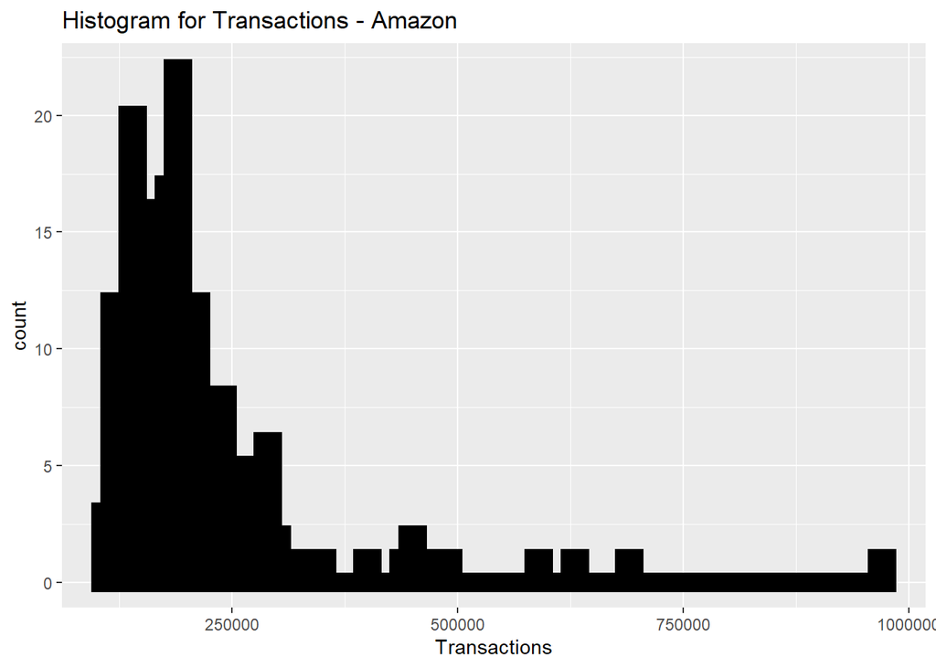

Histogram for Transactions - Amazon

```r
ggplot(data = Price_Amazon, aes(x= Transactions)) +
  geom_histogram(fill="lightblue", color="black", size = 5, binwidth = 10000)+
  labs(title = "Histogram for Transactions - Amazon")
```

The daily transaction has a bell curve distribution with a long tail. Most of the daily transaction falls in the range between (0, 250,000).

# Wrap-Up

In this vignette, we developed several functions to extract stock market data from the Financial Data API. We accessed the stock price and news data for Apple, Amazon, JPMorgan, and Wells Fargo company, then performed some basic EDA to explore some patterns. There are some initial findings. For example, we found that financial companies have a more stable stock price than technical companies. While Technical companies have more exposure in press than financial companies.